# Statsmodel을_활용한_ARIMA_모델_

- 이번에는 Statsmodels의 ARIMA Function 을 이용해서 대한 민국의 최대 전력 수요 예측 실시
- 참고 자료 :
1. https://byeongkijeong.github.io/ARIMA-with-Python/
2. https://otexts.com/fppkr/non-seasonal-arima.html
3. https://www.youtube.com/watch?v=rlfMD3t5qiY&list=PL9mhQYIlKEhd60Qq4r2yC7xYKIhs97FfC&index=6&ab_channel=SKplanetTacademy 4.https://h3imdallr.github.io/2017-08-19/arima/
- 최대 전력 소스 위치
1. http://epsis.kpx.or.kr/epsisnew/selectEkgeEpsMepGrid.do?menuId=040101

About ARIMA :

- ARIMA는 Autoregressive + Intgrate + Moving Average의 통합 모델
- Autoregressive 는 자신의 과거 데이터 기반으로 회귀하고
- Intergrate는 차분을 통해 시계열을 안정화 시킨다.
- Movig Average 를통해 자신의 트랜드를 반영 한다.

시계열 데이터는 일반적으로 불안정 (Non-stationary) 함으로 차분을 통해 안정화 시키고 AR 과 MR을 복합 적으로 적용하여 미래를 예측

- Differencing : 어렵게 생각하지 말자 개별 데이터를 일정한 간격으로 빼서 차이를 통해 Trend 와 Seasnonlity를 삭제 한다.
- 단 differecing 을 많이 하면 1st 면 첫번째 데이터 , 2st 면 두번째 데이터 등을 손실하게 됨으로 일반적으로 3회 이상 진행 하지 않음

ARIMA(p,d,q)(P,D,Q)M : 모수 찾기

- ARIMA 모델을 사용하기 위해서는 p,d,q 의 초이 값을 정해 줘야 한다.
- p : AR(p) 이고 t 시점과 이전 시점과의 회귀 모델 함수
- d : 위에서 말한 differecing 의 d
- q : MA(q) 이고 t 시점과 이전 시점의 moving average 의 잔차의 값의 예측 통상적으로 p + q < 2, p * q = 0 인 값들을 많이 사용한다.

여기서 p * q = 0 이라 하면, 두 값중 하나는 0이라는 이야기이다. ARIMA는 AR모형과 MA모형을 하나로 합쳤다면서 둘 중 하나의 모수가 0인건 또 무슨소리? 라고 할지 모르겠지만, 실제로 대부분의 시계열 자료에서는 하나의 경향만을 강하게 띄기 때문에, 이렇게 사용하는것이 더 잘 맞는다고 한다.

p,d,q 값을 찾는 법 :

- 차분을 통해 I(d)값을 정한다.
- AutoCorrelation 플롯과 Partial Autocorrelation 플롯의 절단점을 통해 p,q 값을 결정 한다.

```python
# 분석에 필요한 라이브러리 호출

import pandas as pd # 판다스 호출
import numpy as np  # 넘파이 호출
import statsmodels.api as sm # statsmodels 호출
import seaborn as sns # 그래프를 그리기위한 Seaborn 호출
from statsmodels.tsa.seasonal import seasonal_decompose # 데이터 필터 라이러리 호출
import matplotlib.pyplot as plt
```

```python
# 구글 드라이브 마운트
from google.colab import drive
drive.mount('/content/drive')
```

```python
# 데이터 호출 함수
def readData (path):
  df = pd.read_excel(path)
  return df
```

```python
# 분석에 사용할 시간별 대한민국 전력 수요 데이터 호출
path = './drive/MyDrive/Study/시계열 데이터/일간최대전력실적.xlsx'
need_df = readData(path)
study_df = pd.DataFrame()
study_df['MaxPower(MW)'] = need_df['최대전력(MW)']
study_df['time'] = need_df['최대전력기준일시']
study_df
```

|  | MaxPower(MW) | time |
| --- | --- | --- |
| 0 | 91141 | 2021/07/27(18:00) |
| 1 | 89426 | 2021/07/26(18:00) |
| 2 | 76521 | 2021/07/25(20:00) |
| 3 | 78285 | 2021/07/24(20:00) |
| 4 | 89812 | 2021/07/23(17:00) |
| ... | ... | ... |
| 934 | 69496 | 2019/01/05(11:00) |
| 935 | 84746 | 2019/01/04(10:00) |
| 936 | 84196 | 2019/01/03(10:00) |
| 937 | 82437 | 2019/01/02(10:00) |
| 938 | 65493 | 2019/01/01(24:00) |

939 rows × 2 columns

```python
# 시간 데이터 타입 확인
study_df.info()
```

```
<class 'pandas.core.frame.DataFrame'>
RangeIndex: 939 entries, 0 to 938
Data columns (total 2 columns):
 #   Column        Non-Null Count  Dtype
---  ------        --------------  -----
 0   MaxPower(MW)  939 non-null    int64
 1   time          939 non-null    object
dtypes: int64(1), object(1)
memory usage: 14.8+ KB
```

```python
# time을 시계열 데이터로 변경
study_df['time'] = study_df['time'].str[0:10]
study_df['time'] = pd.to_datetime(study_df['time'])
study_df.set_index('time',drop=True,inplace=True)
study_df = study_df.sort_index()
study_df
```

| time | MaxPower(MW) |
| --- | --- |
| 2019-01-01 | 65493 |
| 2019-01-02 | 82437 |
| 2019-01-03 | 84196 |
| 2019-01-04 | 84746 |
| 2019-01-05 | 69496 |
| ... | ... |
| 2021-07-23 | 89812 |
| 2021-07-24 | 78285 |
| 2021-07-25 | 76521 |
| 2021-07-26 | 89426 |
| 2021-07-27 | 91141 |

939 rows × 1 columns

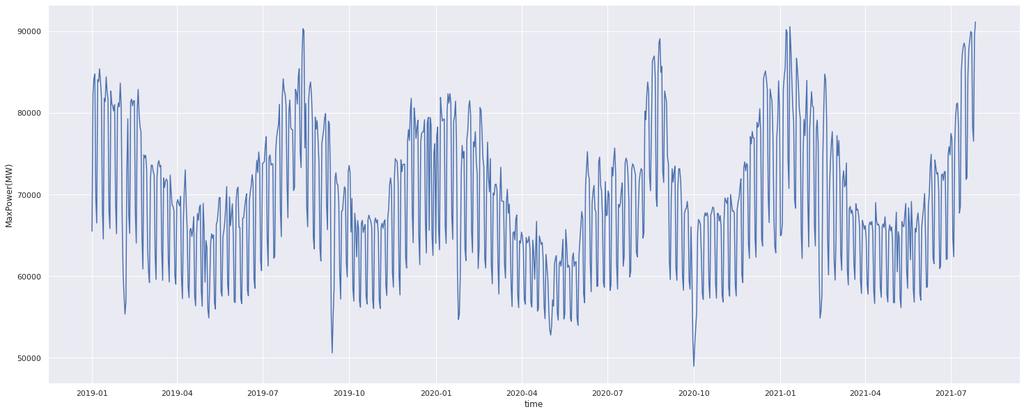

```python
# 최대 전력 수요 가시화
sns.set(rc={'figure.figsize':(25,10)})
sns.lineplot(x=study_df.index , y=study_df['MaxPower(MW)'])
```

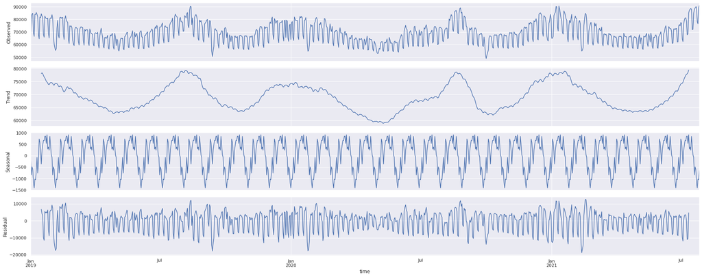

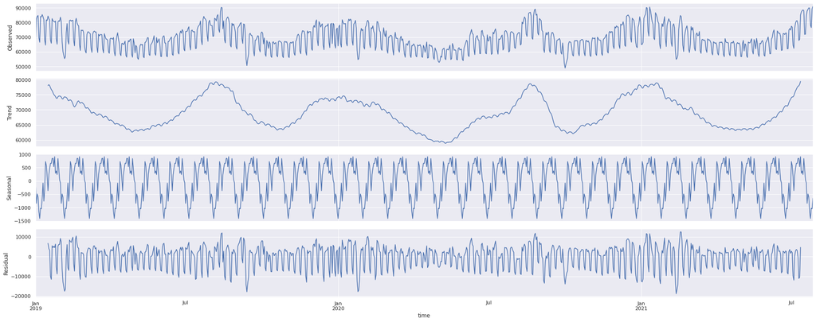

```python
# Seasnonl Decompose 모델로 시계열 육안 확인
result = seasonal_decompose(study_df, model='Mulitiolicative', freq= 30) # 대략 1달치 기준으로 데이터 분해 실시
result.plot()

# 월간 시계열성이 강하다.
```

- ARIMA 모델을 사용하기 위해서 시계열 데이터가 정상상태 인지 확인하기 위해 Augmented Dickey Fuller (ADF) Test를 실시 한다.
- Statsmodel 의 adfuler 모듈을 활용하여 쉽게 값을 구한다.

```python
# 데이터 정상 상태 수치 확인
from statsmodels.tsa.stattools import adfuller #ADF Test를 위한 함수 호출

st_result = adfuller(study_df['MaxPower(MW)'])
print(st_result)

study_df['1st diff'] = study_df['MaxPower(MW)']- study_df['MaxPower(MW)'].shift(1)

# Test 결과 이미 P-Velue 가 0.05 이하 임으로 시계열 데이터가 정상 상태로 판다.
# 만약 0.05 이상 이라면 차분을 통해 시계열 안정화 실시
```

```
(-2.8648766784005697, 0.04958746836469044, 21, 917, {'1%': -3.437501253878553, '5%': -2.864696995470416, '10%': -2.568450985005155}, 17312.592032968387)
```

```
4.549289812479293e-12
```

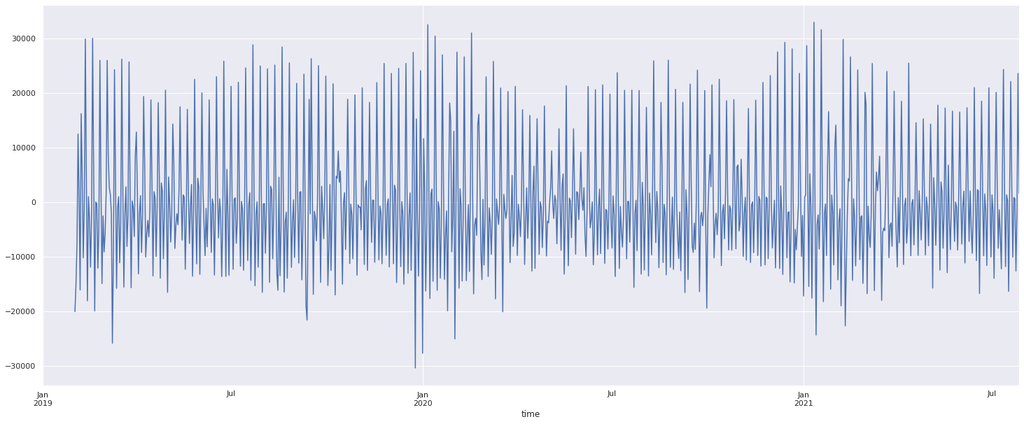

```python
# diff 값으로 계절성 값 계산

study_df['seasonal diff'] = study_df['1st diff'] - study_df['1st diff'].shift(30)
st_result = adfuller(study_df['seasonal diff'].dropna()) # 차분에 의해 발생한 Na 값을 제거 하고 진행
print(st_result[1])
study_df['seasonal diff'].plot()

# 결론적으로 ARIMA의 차분 값은
#d = 0, D = 1 사용
```

Auto Correlation Plot : 시계열 데이터에서 특정 시간 만큼 지연되 데이터와의 상관 성을 그래프트 보여줌

ACF 와 PACF 그래프를 통해 적절한 ARIMA의 모수를 결정해 보자

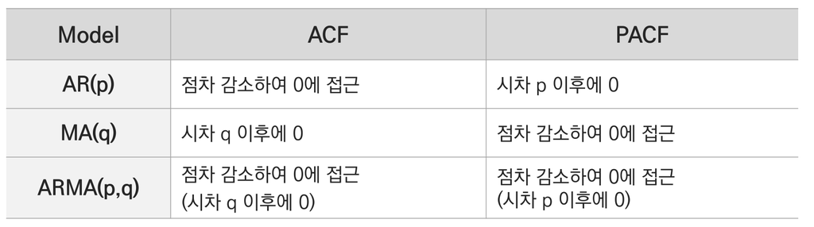

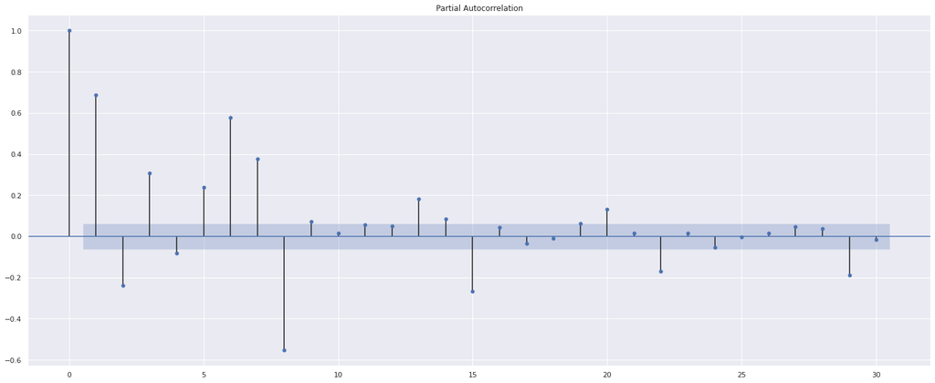

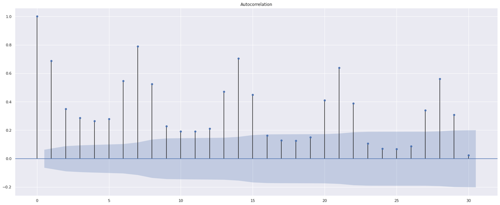

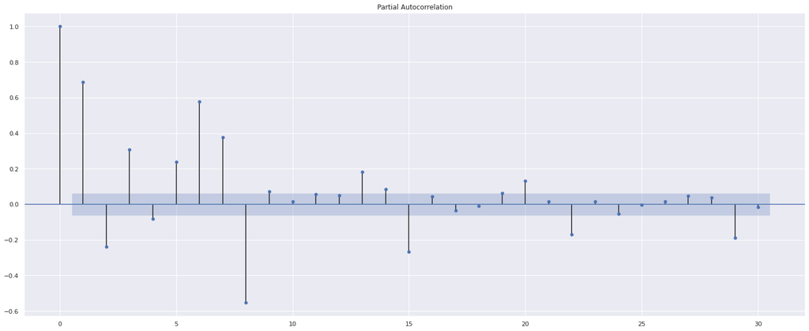

```python
# ACF 그려 보기 / PACF
from statsmodels.graphics.tsaplots import plot_acf, plot_pacf # acf 와 pacf 시각화를 위한 라이브러리 호출

plot_acf(study_df['MaxPower(MW)'])
plot_pacf(study_df['MaxPower(MW)'])
```

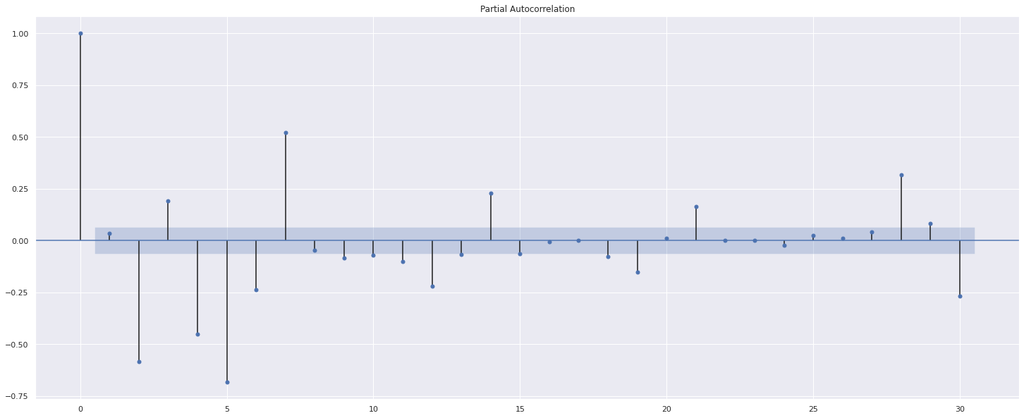

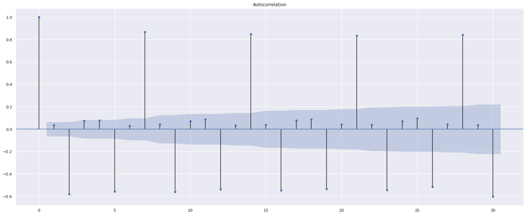

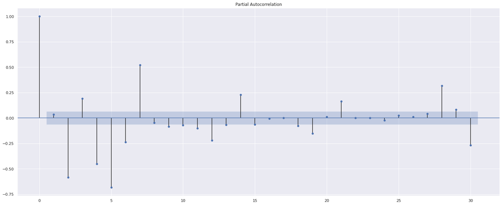

```python
# ACF 그려 보기 / PACF (계절성)

plot_acf(study_df['seasonal diff'].dropna())
plot_pacf(study_df['seasonal diff'].dropna())
```

```python
# Arima 예측
from statsmodels.tsa.arima_model import ARIMA

model = ARIMA(study_df['MaxPower(MW)'], order=(0,2,1))
model_fit = model.fit(trend='nc',full_output=True, disp=1)
print(model_fit.summary())
```

```
                             ARIMA Model Results
==============================================================================
Dep. Variable:        D2.MaxPower(MW)   No. Observations:                  937
Model:                 ARIMA(0, 2, 1)   Log Likelihood               -9578.656
Method:                       css-mle   S.D. of innovations           6635.044
Date:                Mon, 02 Aug 2021   AIC                          19161.312
Time:                        14:17:21   BIC                          19170.997
Sample:                    01-03-2019   HQIC                         19165.005
                         - 07-27-2021
=========================================================================================
                            coef    std err          z      P>|z|      [0.025      0.975]
-----------------------------------------------------------------------------------------
ma.L1.D2.MaxPower(MW)    -0.9999      0.003   -377.007      0.000      -1.005      -0.995
                                    Roots
=============================================================================
                  Real          Imaginary           Modulus         Frequency
-----------------------------------------------------------------------------
MA.1            1.0001           +0.0000j            1.0001            0.0000
-----------------------------------------------------------------------------
```

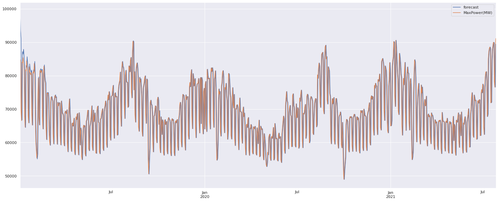

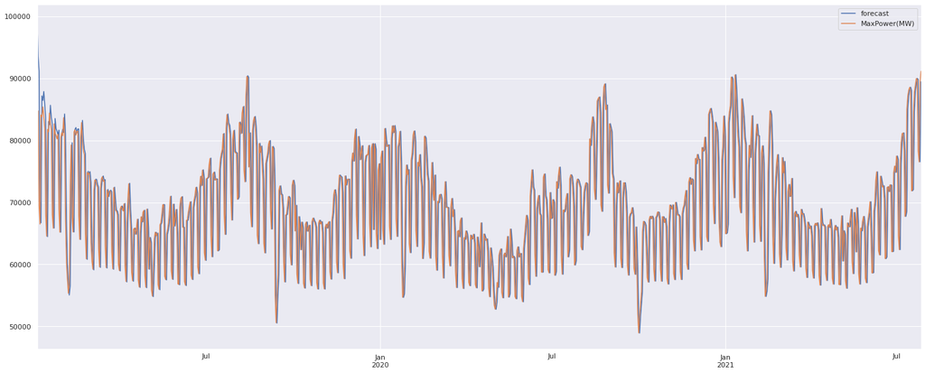

```python
# 시각화 하기
model_fit.plot_predict()
```

```python
# 미래 예측 및 종료
# 19~20년 까지 데이터를 활용하여 ARIMA로 예측하고 21년도 데이터와 오차 계산해 보자

df_1920 = study_df['2019-01':'2020-12']

model = ARIMA(df_1920['MaxPower(MW)'], order=(0,1,1))
model_fit = model.fit(trend='c',full_output=True, disp=1)
fore = model_fit.forecast(steps=27,alpha=0.05)
fore_df = pd.DataFrame()
result_df = study_df['2021-07':'2021-08']
fore_df['Real'] = result_df['MaxPower(MW)']
fore_df.reset_index(drop=False)
fore_df['ARIMA'] = fore[0]
temp_df = study_df['2020-07-01':'2020-07-27'].reset_index()
fore_df.reset_index(inplace=True)
fore_df['20year'] = temp_df['MaxPower(MW)']*1.05
```

```python
fore_df
```

|  | time | Real | ARIMA | 20year |
| --- | --- | --- | --- | --- |
| 0 | 2021-07-01 | 77476 | 79626.348223 | 70885.50 |
| 1 | 2021-07-02 | 76865 | 79647.086603 | 73956.75 |
| 2 | 2021-07-03 | 64612 | 79667.824983 | 73453.80 |
| 3 | 2021-07-04 | 62368 | 79688.563363 | 61153.05 |
| 4 | 2021-07-05 | 76256 | 79709.301743 | 61822.95 |
| 5 | 2021-07-06 | 79663 | 79730.040122 | 76997.55 |
| 6 | 2021-07-07 | 81086 | 79750.778502 | 75878.25 |
| 7 | 2021-07-08 | 81187 | 79771.516882 | 78089.55 |
| 8 | 2021-07-09 | 78397 | 79792.255262 | 79458.75 |
| 9 | 2021-07-10 | 67726 | 79812.993642 | 76128.15 |
| 10 | 2021-07-11 | 68518 | 79833.732022 | 64576.05 |
| 11 | 2021-07-12 | 85011 | 79854.470402 | 61331.55 |
| 12 | 2021-07-13 | 87172 | 79875.208782 | 72209.55 |
| 13 | 2021-07-14 | 88087 | 79895.947162 | 71879.85 |
| 14 | 2021-07-15 | 88551 | 79916.685542 | 72399.60 |
| 15 | 2021-07-16 | 88015 | 79937.423922 | 74034.45 |
| 16 | 2021-07-17 | 71849 | 79958.162302 | 74988.90 |
| 17 | 2021-07-18 | 72054 | 79978.900682 | 64264.20 |
| 18 | 2021-07-19 | 84586 | 79999.639062 | 65495.85 |
| 19 | 2021-07-20 | 87841 | 80020.377442 | 77490.00 |
| 20 | 2021-07-21 | 88937 | 80041.115822 | 78172.50 |
| 21 | 2021-07-22 | 89958 | 80061.854202 | 77816.55 |
| 22 | 2021-07-23 | 89812 | 80082.592581 | 76170.15 |
| 23 | 2021-07-24 | 78285 | 80103.330961 | 72871.05 |
| 24 | 2021-07-25 | 76521 | 80124.069341 | 62884.50 |
| 25 | 2021-07-26 | 89426 | 80144.807721 | 63606.90 |
| 26 | 2021-07-27 | 91141 | 80165.546101 | 76656.30 |

```python
mod = sm.tsa.statespace.SARIMAX(df_1920['MaxPower(MW)'].shift(1), order=(2,1,2),seasonal_order=(0,1,0,30)).fit()
```

```python
print(mod.summary())
```

```
                                 Statespace Model Results
==========================================================================================
Dep. Variable:                       MaxPower(MW)   No. Observations:                  731
Model:             SARIMAX(2, 1, 2)x(0, 1, 0, 30)   Log Likelihood               -7326.933
Date:                            Mon, 02 Aug 2021   AIC                          14663.866
Time:                                    14:17:28   BIC                          14686.621
Sample:                                01-01-2019   HQIC                         14672.662
                                     - 12-31-2020
Covariance Type:                              opg
==============================================================================
                 coef    std err          z      P>|z|      [0.025      0.975]
------------------------------------------------------------------------------
ar.L1          0.1191      0.055      2.146      0.032       0.010       0.228
ar.L2         -0.2523      0.050     -5.017      0.000      -0.351      -0.154
ma.L1         -0.0200      0.038     -0.533      0.594      -0.094       0.054
ma.L2         -0.5687      0.042    -13.612      0.000      -0.651      -0.487
sigma2       7.12e+07   3.12e-10   2.28e+17      0.000    7.12e+07    7.12e+07
===================================================================================
Ljung-Box (Q):                     1727.97   Jarque-Bera (JB):               124.05
Prob(Q):                              0.00   Prob(JB):                         0.00
Heteroskedasticity (H):               0.58   Skew:                             0.00
Prob(H) (two-sided):                  0.00   Kurtosis:                         5.06
===================================================================================

Warnings:
[1] Covariance matrix calculated using the outer product of gradients (complex-step).
[2] Covariance matrix is singular or near-singular, with condition number  5e+32. Standard errors may be unstable.
```

```python
df = pd.DataFrame()
df['ARIMA'] = mod.predict(start = 365*2+1, end= 365*2+30, dynamic= True)
```

```python
real = study_df['2021-01':'2021-01']
df['Real'] = real['MaxPower(MW)']
```

```python
df['erro'] = (df['ARIMA'] - df['Real']) / df['ARIMA'] * 100
```

```python
erro = abs(df['erro']).mean()
```

```python
erro
```

```
14.422144862924338
```